# Replication of below article’s Data and Visualizations “Has International Travel to the U.S. Really Collapsed?” By [Josh Holder, Niraj Chokshi and Samuel Granados](https://www.nytimes.com/interactive/2025/04/30/world/us-travel-decline.html) Karim K. Kardous

- Show All Code
- Hide All Code
- View Source

## *International Travel Into the US Prelude*

**About the data/article in a nutshell:** This New York Times article, backed by numbers from government agencies for the US & Canada, attempts to show whether International Travel into the US has dipped as a result of President Trump’s administration and policies relating to broad tariffs, tight border control, etc.  
The **main takeaway** is that while travel originating from Asia into the United States has timidly increased, that from Europe has stalled, meanwhile that of Canada has sharply decreased, especially when it comes to car crossings into the US; relative to air travel.  
Despite a drastic drop for US bound travel from Canada, overall, travel into the United States has remained fairly undisturbed.

On my choices here, I decided to replicate/plot all outputs (minus the second one) with at best identical data points and visuals, and/or matching as much as possible the ones that were PNG (images) embedded into the article (as opposed to scrips/tables/or otherwise HMTL wrappers containing actual data points). With a solid few weeks time span having passed between article publication date and the time of this writing, and given that the numbers reported at the time were fairly recent, numbers on March 2025 when the article gets published in April 2025, any preliminary numbers that might have got adjusted since then will not allow for 100% match in said numbers.

The one piece that I don’t replicate in this project is the second one; “International arrivals at major U.S. airports”; it’s embedded into the article as a PNG, and would require a lot of work to reverse engineer the foundational data series behind it after scanning said PNG; but more importantly, I try to go for replicating new/unconventional visualizations when this one specifically, at the end of the day, albeit powerful, boils down to a couple of line plots.  
If you like to give the original article a read, you can find it [here](https://www.nytimes.com/interactive/2025/04/30/world/us-travel-decline.html).

Below code chunk loads in libraries used and configures and activates/sets a couple of themes to be used throughout the code

```r
#|echo: false
#|message: false
#|warning: false
#|include: false
# check if the required package 'emo' is installed;
# if not, it might mean your renv environment is not fully restored.
# running `renv::restore()` will install all necessary packages
# to ensure consistent package versions for building this quarto document,
# effectively 'containerizing' your project and protecting it from future package changes.
if (!requireNamespace("emo", quietly = TRUE)) {
  message("\nIt looks like your environment might not be restored.\nRun `renv::restore()` to install required packages.\n")
}

# load packages
library(xml2)
library(downlit)
library(gdtools)
library(tidyverse)
library(quarto)
library(chromote)
library(here)
library(tidycensus)
library(janitor)
library(purrr)
library(ggtext)
library(ggshadow)
library(ggiraph)
library(gfonts)
library(showtext)
library(ggborderline)
library(grid)
library(patchwork)
library(shiny)
library(rvest)
library(htmltools)
library(gt)
library(rsvg)
library(magick)
library(stringr)
library(ggimage)
library(qs)
library(emo)

font_add(family = "franklin-medium", regular = "renv/library/macos/R-4.5/aarch64-apple-darwin20/sysfonts/fonts/Libre_Franklin/static/LibreFranklin-Medium.ttf")

theme_set_custom <- function() {

  # loading google Fonts
  sysfonts::font_add_google("Libre Franklin", "franklin")
  sysfonts::font_add(
    family = "franklin-medium",
    regular = "renv/library/macos/R-4.5/aarch64-apple-darwin20/sysfonts/fonts/Libre_Franklin/static/LibreFranklin-Medium.ttf"
  )
  showtext::showtext_auto()

  # applying ggplot2 theme
  ggplot2::theme_set(
    ggplot2::theme_minimal(base_family = "franklin") +
      ggplot2::theme(
        panel.background = ggplot2::element_rect(fill = "#F9F9F9", color = NA),
        plot.background = ggplot2::element_rect(fill = "#F9F9F9", color = NA)
      )
  )
}

theme_set_custom()
```

## **Travel Score Cards**

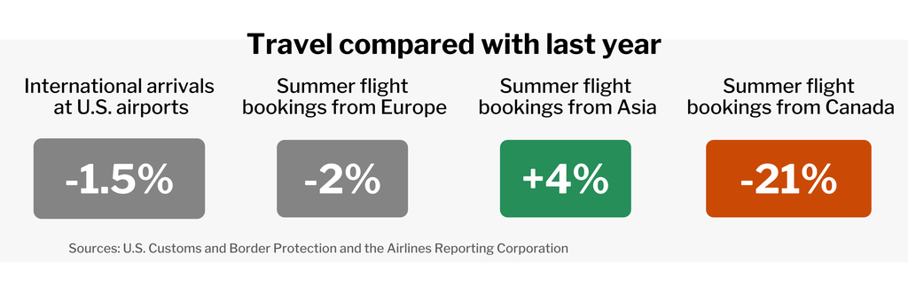

```r
#|echo: false
#|message: false
#|warning: false
#|include: true

theme_set_custom()

p1_tribble <- tribble(
  ~perc_change, ~label, ~region, ~fill, ~width_cm, ~ length_cm,
  '-1.5%', 'International arrivals\n at U.S. airports', 'International','#969696', 170 / 300 * 2.54, 80 / 300 * 2.54, # converting into actual cm, controlling for resolution set (300 or print quality)
  '-2%', 'Summer flight\n bookings from Europe', 'Europe', '#969696', 130 / 300 * 2.54, 77 / 300 * 2.54,
  '+4%', 'Summer flight\n bookings from Asia', 'Asia', '#2b9d6c', 130 / 300 * 2.54, 77/ 300 * 2.54,
  '-21%', 'Summer flight\n bookings from Canada', 'Canada', '#d65f00', 164 / 300 * 2.54, 77 / 300 * 2.54
)

# here i go for an interactive process whereby each plot is created separately in a list of plots; one main reason is that the boxes/rectangles are of different sizes.
tile_plot_rounded <- function(perc_change, label_text, fill, width_cm, length_cm, scaler = 3) { # 3 was best here
  library(grid) # for some reason, roundrectGrob() wasn't running without first loading grid here too (even if called earlier when loading all packages)
  ggplot() +
    ggtitle(label_text) + # set the label as thes plot sub-title
    annotation_custom(
      grob = roundrectGrob(
        width = unit(width_cm * scaler, "cm"),
        height = unit(length_cm * scaler, "cm"),
        r = unit(0.1, "npc"),  # corner radius, the higher the values the more prononcoumced the roundedness
        gp = gpar(fill = fill, col = NA)
      ),
      xmin = 0, xmax = 6, ymin = 0, ymax = 3
    ) +
    annotate(
    "text",
      x = 3, y = 1.5,
      hjust = 0.5, vjust = 0.5,
      size = 10, # text size for perc_change
      label = perc_change,
      color = 'white',
      family = 'franklin',
      fontface = 'bold'
    ) +
    xlim(0, 6) + ylim(0, 3) +
    coord_fixed(ratio = 1) +
    theme_void() +
    theme(
      plot.margin = margin(4, 2, 2, 2), # small margins add around each plot for more subtitle room
      plot.title = element_text(hjust = 0.5, size = 14, family = 'franklin-medium', margin = margin(b = 5)) # this is a midway font face between plain and bold
    )
}
# loop through labels, fills, and dimensions, and including 'label' for the title
tile_plots <- pmap(
  list(
    perc_change = p1_tribble$perc_change,
    label_text = p1_tribble$label,
    fill = p1_tribble$fill,
    width_cm = p1_tribble$width_cm,
    length_cm = p1_tribble$length_cm
  ),
  tile_plot_rounded
)

# assign one row so that all plots are side by side and not potentially stacked (vertically)
p1 <- wrap_plots(
  tile_plots, nrow = 1
)
# adds after wrap a title
p_final <- p1 +
  plot_annotation(
    title = 'Travel compared with last year',
    caption = 'Sources: U.S. Customs and Border Protection and the Airlines Reporting Corporation',
    theme = theme(
      plot.title = element_text(size = 20, family = 'franklin', face = "bold", hjust = 0.5, margin = margin(t = -10, b = 10)),
      plot.caption = element_text(size = 9, family = 'franklin-medium', face = 'bold', colour = '#727272', hjust = 0.15)
      )
  )
p_final
```

## **Confidence, but Warning Signs**

For the below visualization, I opted to use gt() from [gt](https://gt.rstudio.com) package as it naturally comes to mind when trying to build ‘great tables’, yes pun intended. A few things to mention here to explain my thought process.

- Clearly the tables go over the left/right margins of the article layout in the original. While our dimensions may allow for all 3 tables to fit side by side, for replication purposes, we ‘push out’ the margins or reduce them to make them all 3 tables fit side by side.
- Second, one other thing that stands out is the clear customization of the third column, the percent change actual values, where a target bar plot of some sort is drawn. To replicate that, one way (potentially only way) is to use `text_transform()`, in tandem with a custom function using `fn` argument that will incorporate mostly css code. This allows for greater customization down to the minutiae.
- Said last column is also centered and anchored using a small vertical tick (this is most visible in the middle plot where values alternate between negative (left) and positive (right) of tick.
- From the tick each value is gauged on their max for that table, to get a sense of proportionality and make sure each bar’s no. of pixels proportionally match to the greatest (absolute) value per table.

Below I show the code that pulls int the data, embedded in an html table; so that once the node or in this case `css` element name is identified, the rest is fairly easy.

```r
#|echo: false
#|message: false
#|warning: false
#|include: true

## p3; table to embed in gt()
# read in the correspoinding table node
url <- 'https://www.nytimes.com/interactive/2025/04/30/world/us-travel-decline.html'
raw_table <-
  read_html(url) |>
  html_element(css = '.svelte-5z6yzk') |>
  html_table() |>
  select(country = 1, perc_change = 2) |>
  filter(perc_change != '')

# processing the tibble
individual_country_changes <-
  raw_table |>
  mutate(
    perc_change_num = parse_number(perc_change),
    left_right_ended = if_else(perc_change_num <= -.02, 'left', 'right'),
    # below also going to be used to section off the table into 3 columns
    change_direction = case_when(
      between(perc_change_num, -2, 1) ~ 'stalled',
      perc_change_num < 0 ~ 'decreased',
      .default = 'increased')
  ) |>
  mutate(
    groupings = case_when(
      n() == 11 ~ 1,
      n() ==  6 ~ 2,
      .default = 3),
    .by = change_direction
    )
```

```r
#|echo: false
#|message: false
#|warning: false
#|include: false
#|results: 'asis'

gt_table_custom_ <- function(hex, direction, title = NULL) {

  title_ <- title
  hex_to_pass_in_fn <- hex
  dir_to_pass_in_fn <- direction

  individual_country_changes |>
    filter(groupings == {{direction}}) |>
    select(1:3) |>
    gt() |>
    text_transform(
      locations = cells_body(columns = perc_change_num),
      fn = function(x) {
        x_num <- as.numeric(x)
        max_val <- max(abs(x_num), na.rm = TRUE)
        if(max_val == 0) max_val <- 1
        widths_for_glue <- abs(x_num) / max_val * if (dir_to_pass_in_fn == 2) 8 else 100 # default scaling may look misleaading for 'no change' countries, so massively reduced here otherwise center table values get way inflated for what they are ([-2; 1])

        # loop thru values of perc_change column and isolate each element so that it can pass thru str_glue() without length(x) > 1 error from if/else statement
        purrr::map_chr(seq_along(x_num), function(x) {
          width <- widths_for_glue[x]
          val <- x_num[x]

          if(dir_to_pass_in_fn == 2) {
            direction_to_go <- if(val < 0) "right" else "left"
            translate_offset <- if(val <= -2) "20%" else "0" # translate back to the origin for values >= -.02 (this gets applied only for no-change countries/middle table)
            str_glue(
              '<div style="display: flex; align-items: center; justify-content: center;">
                 <div style="position: relative; width: 100%; height: 8px;">
                   <div style="position: absolute; left: 50%; top: -4px; bottom: 4px;width: 2px; height: 16px; background: #ccc;"></div>
                   <div style="position: absolute; {direction_to_go}: 50%; top: 0;
                               background: {hex_to_pass_in_fn}; height: 8px; width: {width}%;
                               transform: translateX({translate_offset});
                               border-radius: 3px;"></div>
                 </div>
               </div>'
            )
          }  # for below, we treat direction 1 (very negative change) and 2 (very positive) virtually the same, only former goes from center to left while latter from center to right
          else {
            direction_to_go <- if(direction == 1) "right" else "left"
            str_glue(
              '<div style="display: flex; align-items: center; justify-content: center;">
                 <div style="position: relative; width: 50%; height: 8px;">
                   <div style="position: absolute; left: 50%; top: -8px; width: 2px; height: 16px; background: #ccc; transform: translateX(-1px);"></div>
                   <div style="position: absolute; {direction_to_go}: 50%; top: -4px; background: {hex_to_pass_in_fn}; height: 8px; width: {width}%; border-radius: 3px;"></div>
                 </div>
               </div>'
            )
          }
        })
      }
    ) |>
    cols_align(
      align = "center",
      columns = perc_change
    ) |>
    tab_style(
      style = cell_text(color = hex),
      locations = cells_body(columns = perc_change)
    ) |>
    tab_style(
      style = css("white-space" = "nowrap"),
      locations = cells_body(columns = country)
      ) |>
    cols_label(
      country = md("**Country**"),
      perc_change = "",
perc_change_num = htmltools::HTML("<span style='white-space: nowrap;'><strong>Change vs. 2024</strong></span>")
) |>
    opt_table_font(
      font = c("franklin-medium"),
      weight = 500
    ) |>
    tab_options(
      heading.align = "left",
      table.width = pct(100),
      heading.padding = px(10),
      table.border.top.style = "hidden",
      column_labels.border.bottom.style = "solid",
      column_labels.border.bottom.width = px(1),
      column_labels.border.bottom.color = "white",
    ) |>
    cols_width(
    country ~ pct(50),
    perc_change ~ pct(50),
    perc_change_num ~ pct(50)
    )
}

# generate and assign tables below
tbl1 <- gt_table_custom_(hex = '#d65f00', direction = 1) |>
  tab_header(
    title = md("**Where U.S.-bound summer flight bookings have <span style='color: #d65f00;'> decreased </span>...**")
  )
tbl2 <- gt_table_custom_(hex = '#666666', direction = 2) |>
  tab_header(
    title = md("<span style='color: #666666;'>**... stayed about the same ...**</span>")
    # subtitle = md("<span style='color: #FFFFFF;'>adding artificial padding.**</span>")
  )

tbl3 <- gt_table_custom_(hex = '#2b9d6c', direction = 3) |>
    tab_header(
    title = md("**... and <span style='color: #2b9d6c;'>increased</span>.**")
    # subtitle = md("<span style='color: #FFFFFF;'>adding artificial.** padding</span>")
  )

tables_row_layout <- htmltools::tags$div(
  style = "display: flex; justify-content: space-between; align-items: flex-start; gap: 20px; width: 100%; padding: 0 10px;",
  htmltools::tags$div(style = "flex: 1; min-width: 0;", tbl1),
  htmltools::tags$div(style = "flex: 1; min-width: 0;", tbl2),
  htmltools::tags$div(style = "flex: 1; min-width: 0;", tbl3)
)

caption_text <- "<span style='color:#707070;'>Source: Airlines Reporting Corporation &bull; Data covers flight bookings made between Feb. 1 and April 13 for travel between Memorial Day and Labor Day, compared to the same period last year.</span>"
caption_html_content <- HTML(caption_text)
left_padding_value <- "20px" # adding some padding so that caption moves slightl to the right to match original's caption poisiton

caption_styled_div <- htmltools::tags$div(
  style = paste(
    "width: 50%;",  # overall visual span
    "max-width: 1000px;", # cap the max width of the caption
    "margin: 5px auto 0 auto;",
    "text-align: left;",
    "font-family: 'franklin-medium', 'Libre Franklin', Arial, sans-serif;", # prioritize 'franklin-medium'
    "font-weight: 500;",
    "font-size: 0.85em;",
    "line-height: 1.1;",
    paste0("padding-left: ", left_padding_value, ";")
  ),
  caption_html_content
)

# parent div will stack them vertically and can be used to constrain overall width
overall_final_layout <- htmltools::tags$div(
  style = "width: 100%; max-width: 1900px; margin: 0 auto; padding-bottom: 1px;",
  tables_row_layout,
  caption_styled_div
)
# final output
overall_final_layout
```

**Where U.S.-bound summer flight bookings have decreased …**

| **Country** |  | **Change vs. 2024** |
| --- | --- | --- |
| Canada | -21% |  |
| Netherlands | -17% |  |
| Germany | -12% |  |
| Ecuador | -11% |  |
| Mexico | -9% |  |
| Dom. Rep. | -9% |  |
| Switzerland | -8% |  |
| China | -7% |  |
| South Korea | -5% |  |
| India | -4% |  |
| Poland | -4% |  |

**… stayed about the same …**

| **Country** |  | **Change vs. 2024** |
| --- | --- | --- |
| U.K. | -2% |  |
| France | -2% |  |
| Colombia | -2% |  |
| Italy | 0% |  |
| Philippines | +1% |  |
| Greece | +1% |  |

**… and increased.**

| **Country** |  | **Change vs. 2024** |
| --- | --- | --- |
| Costa Rica | +3% |  |
| Brazil | +4% |  |
| Australia | +6% |  |
| Spain | +8% |  |
| Portugal | +8% |  |
| Japan | +11% |  |
| Ireland | +11% |  |
| Argentina | +39% |  |

Source: Airlines Reporting Corporation • Data covers flight bookings made between Feb. 1 and April 13 for travel between Memorial Day and Labor Day, compared to the same period last year.

Unlike the line graphs from the original article, showing the Intl. Arrivals, where the graph was embedded as an image, here I was able to extract the actual data using the tag id pointing out to the table using [Selector Gadget](https://g.co/kgs/zQmpZoP) - a free reliable Chrome Extension that can be used to identify either the CSS selector or Xpath of site elements - *in tandem* with [rvest](https://rvest.tidyverse.org/) to read in the embedded data from said selector into a tibble.  
Note that within gtExtras, there already is a New York Times custom theme table using `gtExtras::gt_theme_nytimes()`, but did not closely match the style of the headers or the overall style of the tables; however it’s good to know if you are working with your own data (not replicating another piece), and you’re just ready to use a starter template or its boilerplate to at least test how it looks, if nothing else.  
Overallf, I think this is a fairly solid replication of the tables from the original, a piece I’ve enjoyed creating as it involved fairly advanced customization - I’d say it was deceptively simple to re-create, but worth it.  
**One thing to call out** however is that these tables are optimized for desktop viewing due to their 100% width formatting. Mobile users may experience cramped display issues; I will let you in on a secret - it turns out that I do not stand a chance against the Financial might of the NYT !

## **A Canadian boycott**

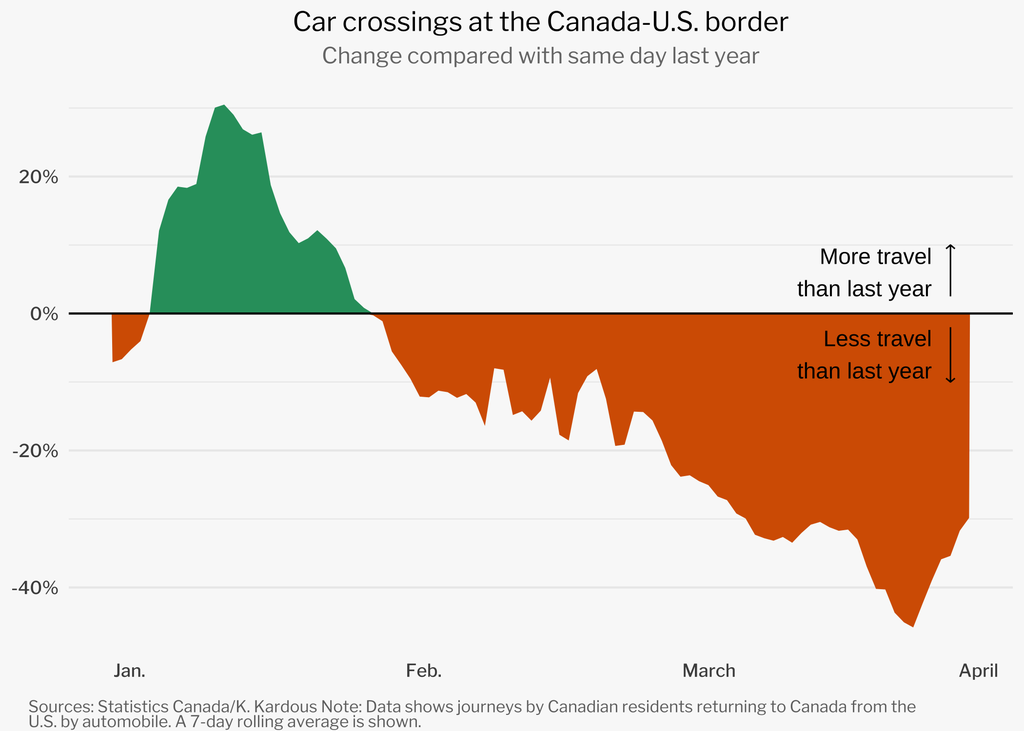

```r
#|echo: false
#|message: false
#|warning: false
#|include: false

theme_set_custom()

car_xing_ca_us_borders_py <- read_csv('car_crossing_ca_us_borders.csv') |>
  distinct()

car_xing_ca_us_borders_cy <- read_csv('car_crossing_ca_us_borders2.csv') |>
  distinct()

# i am testing with below filters
# 1st, 2nd filter should only focus on Canadian nationals and or residents (article focuses on Canadian sentiment; with use of strong word such as boycott, so assuming we should look into Canada returns only, not Intl. returns from US into Canada)
# 3nd filter -> 'Vehicles' is a major group (when 'automobiles' and 'motorcycles' are subgroups) so filtering to 'Vehicles' so that not to inflate the counts, but the plot caption in the original article mentions 'by automobile' so we filter t
# 4rd filter same idea as in 2nd but here -> 'Travellers' is a major group after a quick calculation for one day as an example where all values for that day sumn up to 'Travellers' value

filtered_to_canadian_cy <-
  car_xing_ca_us_borders_cy |>
  filter(
    `Traveller characteristics` == 'Canadian resident visitors returning to Canada' & `Vehicle licence plate` == 'Canadian-plated vehicles entering Canada' & GEO == 'Canada' &
    `Vehicle type` == 'Automobiles' & `Traveller type` == 'Travellers'
    ) |>
  # above combination of filters is giving me exactly 1 record per day (without any aggregations/roll ups) and it also gives me 116 days (Jan 1 through to Apr 26th, so we stick to those filters; likely correct)
  select(
    crossing_date = 1,
    travel_characteristic = 6,
    travel_type = 7,
    vehicle_ttl = ncol(car_xing_ca_us_borders_cy) - 4
    )

# same with py (or prior year)
filtered_to_canadian_py <-
  car_xing_ca_us_borders_py |>
    filter(
    `Traveller characteristics` == 'Canadian resident visitors returning to Canada' & `Vehicle licence plate` == 'Canadian-plated vehicles entering Canada' & GEO == 'Canada' &
    `Vehicle type` == 'Automobiles' & `Traveller type` == 'Travellers'
    ) |>
  select(
    crossing_date = 1,
    travel_characteristic = 6,
    travel_type = 7,
    vehicle_ttl = ncol(car_xing_ca_us_borders_py) - 4
    ) |> # 117 days for py since it was leap year, so we filter out feb 29th to have a day over day comparison
  filter(crossing_date != '2024-02-29')

# combining both sets
car_xing_change <-
  filtered_to_canadian_cy |>
  select(1, last_col()) |>
  arrange(crossing_date) |>
  bind_cols(
    filtered_to_canadian_py |>
      arrange(crossing_date) |>
      select(ly_ttls = last_col())
  ) |>
  mutate(
    change = vehicle_ttl - ly_ttls,
    change_perc = (vehicle_ttl - ly_ttls) / ly_ttls
    ) |>
    filter(crossing_date < '2025-04-10') |>
  # add a rolling 7 day avg
  mutate(
    rolling_avg_7day = zoo::rollmean(change_perc, k = 7, fill = NA, na.rm = TRUE)
    ) |>
  filter(!is.na(rolling_avg_7day))

# first two months get abbreviated followed by a dot, while last two don't get abbreviated
month_custom_labeller <-
  map_chr(
  .x = car_xing_change |>
    pull(crossing_date) |>
    lubridate::month() |>
    unique() |>
    sort(),
  .f = function(x)
    case_when(
      x > 2 ~ month(x, label = TRUE, abbr = FALSE),
      .default = paste0(month(x, label = TRUE, abbr = TRUE), '.')
      )
  )

caption_text <- "<span style='color:#707070;'>Sources: Statistics Canada/K. Kardous Note: Data shows journeys by Canadian residents returning to Canada from the<br> U.S. by automobile. A 7-day rolling average is shown.</span>"

car_xing_change |>
    mutate(
        y_pos = pmax(rolling_avg_7day, 0),  # positive values only; this caps at 0 for < 0 so to create essentially two seperate series (one pos. and one negative)
        y_neg = pmin(rolling_avg_7day, 0)   # negative values only
    ) |>
  ggplot(aes(x = crossing_date)) +
  geom_area(aes(y = y_pos), fill = '#2b9d6c', outline.type = 'lower') +
  geom_area(aes(y = y_neg), fill = '#d65f00', outline.type = 'lower') +
  geom_hline(yintercept = 0) +
  labs(
    x = NULL,
    y = NULL,
    caption = caption_text
    ) +
  scale_y_continuous(
    labels = scales::percent
    ) +
  scale_x_date(
    breaks = seq(as.Date('2025-01-01'), as.Date('2025-04-09'), 'm'),
    labels = month_custom_labeller
    ) +
  # arrow and text for negative region
  annotate(
    geom = "segment",
    x = as.Date('2025-04-04'),
    xend = as.Date('2025-04-04'),
    y = -0.02,
    yend = -0.1,
    colour = "black",
    arrow = arrow(length = unit(0.1, "cm"), angle = 50, type = 'open'),
    linewidth = .35
  ) +
  annotate(
    geom = 'text',
    x = as.Date('2025-04-02'),
    y = -0.06,
    label = 'Less travel\nthan last year',
    hjust = 1,
  ) +
  # arrow and text for positive region
    annotate(
    geom = "segment",
    x = as.Date('2025-04-04'),
    xend = as.Date('2025-04-04'),
    y = 0.025,
    yend = 0.1,
    colour = "black",
    arrow = arrow(length = unit(0.1, "cm"), angle = 50, type = 'open'),
    linewidth = .35
  ) +
    annotate(
    geom = 'text',
    x = as.Date('2025-04-02'),
    y = 0.06,
    label = 'More travel\nthan last year',
    hjust = 1
    ) +
    ggtitle(
    label = "<span style='color:black;'>Car crossings at the Canada-U.S. border",
    subtitle = "<span style='color:#777777;'>Change compared with same day last year"
  ) +
  theme(
    panel.grid.minor.x = element_blank(),
    panel.grid.major.x = element_blank(),
    plot.title = element_markdown(hjust = .5),
    plot.subtitle = element_markdown(hjust = .5),
    plot.caption = element_markdown(
      size = 8, hjust = 0,
      margin = margin(l = -20, r = 10, t = 10, b = -5)
      ),
    axis.text = element_text(family = 'franklin-medium', face = 'bold'),
    axis.text.x = element_text(hjust = -.9)
  )
```

If you look at the original, while the trends overall match unquestionably, meaning the intent/message conveyed here and in the original article is fundamentally the same, there are a few spikes that I did not manage to replicate; while I am confident in my methods; and that the numbers reflect a true 7 day moving average of car crossings; I can only assume some the data has been re-actualized, updated to go from preliminary to definitive in the time ellapsed between article publication and now (as of this writing).

## **Big drops along the border**

**About the data:** You will find the data pushed as 2 separate csv files, one for March 2024, the other for March 2025, and combined as part of the pre-processing steps in the below code. The data tracks the no. of automobiles that crossed the CA -> US large/known border stations, focusing only on ports that with at least 1,000 crossings for 2025. To match the numbers in the article as closely as possible. I applied below filters:

- traveller_type is set to “Travellers” (aggregate roll up)
- traveller_characteristics is set to detect the “Canadian residents” pattern, regardless of direction (going to or returning from the US)
- Wherever specific levels radio filter selection were displayed, I kept them all blank/unchecked
- I had to filter out “British Columbia” returned as part of the [tidygeocoder](https://jessecambon.github.io/tidygeocoder/) wrapper for the `arcgis` API to get approximate/realistic coordinates around which triangles (for YoY changed would be plotted); the reason is that it returned (in that case only) a whole province, when a much smaller geography is needed.  
  For more info on the pull itself, feel free to consult Statistics Canada.

```r
#|echo: false
#|message: false
#|warning: false
#|include: false

library(ggplot2)
library(tidyverse)
library(janitor)
library(rnaturalearth)
library(tidygeocoder)
library(sf)
library(rnaturalearthdata)
theme_set_custom()
# steps to recreate last plot/map displaying drops in border crossings between Canada and US
# tested it on 1 example/1 port with Only ports with at least 1,000 crossings in March 2025
# and the results match the visual to a percentage + or -
## go to below lins for 2024
# https://www150.statcan.gc.ca/t1/tbl1/en/cv!recreate.action?pid=2410005301&selectedNodeIds=1D146,2D3,2D18,2D41,2D42,2D75,2D91&checkedLevels=2D1&refPeriods=20240301,20240301&dimensionLayouts=layout2,layout3,layout2,layout2&vectorDisplay=false
## go to below link for 2025
# https://www150.statcan.gc.ca/t1/tbl1/en/cv!recreate.action?pid=2410005301&selectedNodeIds=1D146,2D41,2D42&checkedLevels=2D1,2D2&refPeriods=20250301,20250301&dimensionLayouts=layout3,layout3,layout3,layout2&vectorDisplay=false

# filters applied to test on Niagara Falls - Queenston Bridge
# " GEOGRAPHY
# Select specific levels only -> keep blank
# Niagara Area -> check only Niagara Falls - Queenston Bridge
#  TRAVELLER CHARACTERISITCS
# Select specific levels only -> keep blank
# Canadian-resident visitors returning to Canada -> check only Canadian residents returning from the United States of America
#  TRAVELLER TYPE
# Keep defaults (all checked; 'Travellers' is a the final rollup number/totl)
#  REFERENCE PERIOD
# March 2024
#
# SAME EXACT STEPS FOR 2025

# DOWNLOAD BOTH AS CSVs and select 'Download selected data (for database loading) "
# (56331 - 103307) / 103307 # Niagara Falls - Rainbow Bridge
# (90202 - 144738) / 144738 # Niagara Falls - Queenston Bridge
# (0.3768 + 0.4547 ) / 2

# let's try to recreate those figures now that we have loaded the full datasets
map_data_ca_xings <-
  read.csv('2024_ca_us_ttl_xing_main_ports.csv') |>
  # mutate(year = 2025) |>
  clean_names() |>
  bind_rows(
    read_csv('2025_ca_us_ttl_xing_main_ports.csv') |>
      # mutate(year = 2024) |>
      clean_names()
  ) |>
  as_tibble()

invisible(
  {
  map_data_ca_xings |>
    mutate(
      ref_year = word(ref_date, 1, sep = '\\-')
    ) |>
    filter(
      traveller_type == 'Travellers' &
        geo %in% c('Niagara Falls - Queenston Bridge', 'Niagara Falls - Rainbow Bridge') &
        str_detect(traveller_characteristics, 'Canadian residents')
    ) |>
    count(ref_year, geo, crossings = value) |>
    summarise(
      perc_change_niagara_busiest_2ports = (
        sum(if_else(ref_year == 2025, crossings, 0)) - sum(if_else(ref_year == 2024, crossings, 0))
      ) /
        sum(if_else(ref_year == 2024, crossings, 0))
    ) # 41% decline - article says 42%; close enough; some values, especially for 2025 may have been preliminary and may have been slightly adjusted
  }
)

# let's create a function now that loops thru all major ports name and generate a port name by % decline (2 column tibble)
port_name_list <- map_data_ca_xings |> pull(geo) |> unique()
perc_change_by_port <- function(x, port_name){

  map_data_ca_xings |>
    mutate(
      ref_year = word(ref_date, 1, sep = '\\-')
    ) |>
    filter(
      traveller_type == 'Travellers' &
        str_detect(traveller_characteristics, 'Canadian residents') &
        geo %in% port_name
    ) |>
    count(ref_year, geo, crossings = value) |>
    filter(crossings >= 1000) |>
    summarise(
      perc_change = (
        sum(if_else(ref_year == 2025, crossings, 0)) - sum(if_else(ref_year == 2024, crossings, 0))
      ) /
        sum(if_else(ref_year == 2024, crossings, 0)),
      .by = geo
    ) |>
    filter(geo != 'Canada' & !is.na(perc_change) & between(abs(perc_change), 0, 1)) |>
    mutate_if(is.numeric, function(x) round(x, 2))
}
port_names_with_perc_changes <- map_dfr(.x = port_name_list, ~ perc_change_by_port(port_name = .x))
# Canada as a whole country, has seen 24% fewer passengers in March 2025 vs. March 2024
# adding lat/longs to then be able to add as a alayer on the map
port_coords <- tribble(
  ~geo, ~latitude, ~longitude,
  "Niagara Falls - Queenston Bridge",        43.1633, -79.0507,
  "Niagara Falls - Rainbow Bridge",          43.0896, -79.0703,
  "Niagara Falls - Whirlpool Bridge",        43.1051, -79.0645,
  "St. Stephen - 3rd Bridge",                45.1856, -67.2792,
  "St. Stephen - ferry and other locations", 45.2025, -67.2783,
  "St-Armand/Philipsburg",                   45.0412, -73.0486,
  "Stanstead: Route 55",                     45.0036, -72.0981,
  "Stanstead: Route 143",                    45.0066, -72.1047,
  "Lacolle: Route 221",                      45.0878, -73.3717,
  "Lacolle: Route 223",                      45.0861, -73.3597,
  "St-Bernard-de-Lacolle: Highway 15",       45.0051, -73.3723,
  "Douglas",                                 49.0033, -122.7578,
  "Pacific Highway",                         49.0038, -122.7382,
  "Abbotsford/Huntingdon",                   49.0027, -122.2555
)
# not run
# port_names_with_perc_changes |>
#   left_join(
#     port_coords
#   ) |>
#   summarise(
#     na_prop = 1 - mean(is.na(latitude))
#     ) # currently only a 10% match rate from online searches, so let's explore tidygeoder package to get more granular
# and see if we can extend the matching to at least 60-70% then we can at least go from there

yet_to_match <- port_names_with_perc_changes |>
  left_join(
    port_coords
  ) |>
  filter(is.na(latitude)) |>
  pull(geo) |>
  str_c(' Canada US border')

# writing an if statement to check if geocode_arcgis is already created a temp qs file, so that we avoid redundant api calls (every time we run/render the doc)
cache_file <- "geocoded.qs"
geocode_arcgis <- if (file.exists(cache_file)) {
  qread(cache_file)
} else {
  geocode_arcgis <- map_dfr(yet_to_match, ~ geo(address = .x, method = "arcgis"))
  qsave(geocode_arcgis, cache_file)
  geocode_arcgis
}

# this massively improved the matches- but let's see if those coordinates realisticall can be considered
# border regions between CA and US
```

```r
# now onto actual building of plot elements that will go into final output

#|echo: false
#|message: false
#|warning: false
#|include: false
#|eval: false
library(ggplot2)
library(tidyverse)
library(janitor)
library(rnaturalearth)
library(tidygeocoder)
library(sf)
library(rnaturalearthdata)
theme_set_custom()

invisible(
  {
    validate_border_crossings <- function(geocoded_df, max_km_from_49th = 200) {

      # canada rough bounds
      canada_lat <- c(41.5, 84.0)
      canada_lon <- c(-141.0, -52.0)

      # simple distance to 49th parallel (main border)
      distance_to_49th <- function(lat) abs(lat - 49.0) * 111  # ~111 km per degree latitude

      geocoded_df |> # geocode_arcgis was here, changed to geocoded_df
        filter(!is.na(lat), !is.na(long)) |>
        mutate(
          within_canada = lat >= canada_lat[1] &
            lat <= canada_lat[2] &
            long >= canada_lon[1] &
            long <= canada_lon[2],

          km_from_49th = distance_to_49th(lat),

          is_valid = within_canada & km_from_49th <= max_km_from_49th,

          status = case_when(
            !within_canada ~ "outside canada bounds",
            km_from_49th > max_km_from_49th ~ paste0("too far out (", round(km_from_49th), "km)"),
            TRUE ~ "valid"
          )
        )
    }

    validated_coords <- validate_border_crossings(geocode_arcgis, max_km_from_49th = 300)
    # using above threshold to sorta account for US 'curvature' into Canada, especially on the North-East region,
    # as the border is not jsut one latitude/'horizontal' line
    valid_coords <-
      validated_coords |>
      filter(is_valid) |>
      select(geo = address, lat, long) # this has moved from 10 matches up to 96 out of 140 ~ 70% match rate
    # looking at no. of spikes in the article, 96 spikes should hopefully cover most if not all location of spikes in
    # the article, which from visual insepction, looks like around 50 are draw/plotted on the Canada/US map/border

    # combine all tibbles into one with perc_changes
    # spike_prep is defined but not explicitly used later, spike_prep_sf is the key one
    spike_prep <- port_names_with_perc_changes |>
      filter(geo != 'British Columbia') |> # filter out BC early
      left_join(
        port_coords,
        join_by(geo == geo)
      ) |>
      left_join(
        valid_coords |>
          mutate(
            geo = str_remove(geo, ' Canada US border')
          ),
        join_by(geo == geo)
      ) |>
      mutate(
        latitude = coalesce(latitude, lat),
        longitude = coalesce(longitude, long)
      ) |>
      filter(!is.na(latitude)) |>
      select(geo:longitude)
  }
)
## starting the work on the map

# get map data
invisible({
  countries <-
    ne_countries(scale = "medium", returnclass = "sf") %>%
    filter(name %in% c("United States of America", "Canada"))
})
invisible(capture.output({
  # get great lakes
  lakes <- ne_download(
    scale = "medium",
    type = "lakes",
    category = "physical",
    returnclass = "sf"
  ) %>%
    filter(
      name %in% c(
        "Lake Ontario", "Lake Erie", "Lake Huron",
        "Lake Michigan", "Lake Superior")
    ) })
)

# crop to focus area - remove alaska
map_bounds <- list(
  xmin = -125, xmax = -65,
  ymin = 41, ymax = 52
)
# filter out Alaska from US (longitude > -140 is roughly Alaska)
continental_us_canada <-
  countries |>
  mutate(
    # create geometries without Alaska
    geometry = case_when(
      name == "United States of America" ~ st_crop(
        geometry, xmin = -130, ymin = 20, xmax = -60, ymax = 50
      ),
      TRUE ~ geometry
    )
  ) |>
  # remove any empty geometries after cropping
  filter(!st_is_empty(geometry))

# combine all tibbles into one with perc_changes
spike_prep_sf <-
  port_names_with_perc_changes |>
  filter(geo != 'British Columbia') |> # filter out "British Columbia" here
  left_join(
    port_coords,
    join_by(geo == geo)
  ) |>
  left_join(
    valid_coords |>
      mutate(
        geo = str_remove(geo, ' Canada US border')
      ),
    join_by(geo == geo)
  ) |>
  mutate(
    latitude = coalesce(latitude, lat),
    longitude = coalesce(longitude, long)
  ) |>
  filter(!is.na(latitude)) |>
  select(geo:longitude) |> # Make sure perc_change is carried through if it exists in port_names_with_perc_changes
  st_as_sf(
    coords = c("longitude", "latitude"),
    crs = 4326, agr = "constant",
    remove = FALSE
  )

# generating regions for easier filtering of spikes
crossing_data <-
  spike_prep_sf |> # This now uses the BC-filtered data
  filter(
    abs(perc_change) <= .50 & longitude >= -122.76 & #exclude far west/Vancouver area and start at Douglas
      !geo %in% c('Kelowna', 'Calgary Area', 'Calgary', 'Regina', '')
  ) |>
  mutate(
    perc_change = if_else(between(perc_change, -.39, -.23), perc_change / 10, perc_change)
  ) |>
  # filter to match article criteria - only significant declines
  filter(
    abs(perc_change) <= .45
  ) %>%
  # add regional grouping for better selection
  mutate(
    region = case_when(
      longitude < -115 ~ "west_coast",
      longitude >= -115 & longitude < -100 ~ "prairie",
      longitude >= -100 & longitude < -85 ~ "central",
      longitude >= -85 ~ "east",
      TRUE ~ "other"
    ),
    normalized_heights = if (n() > 0 && any(!is.na(perc_change))) abs(perc_change) / max(abs(perc_change), na.rm = TRUE) else 0 # handle empty or all NA cases
  )


# select representative spikes by region to match article count (~40-50 total)
selected_spikes <-
  crossing_data |>
  filter(latitude <= 49.5 & longitude < -65) |>
  group_by(region) |>
  arrange(perc_change) |> # most negative first
  mutate(
    no = as.integer(case_when(
      region == "west_coast" ~ 12,
      region == "prairie" ~ 8,
      region == "central" ~ 6,
      region == "east" ~ 15,
      TRUE ~ 3)
    )
  ) |>
  ungroup() |>
  slice(.by = region, 1:no[1]) |>
  select(-no) |>
  bind_rows(
    # pull select positive changes
    crossing_data |>
      filter(perc_change > 0) |>
      filter(longitude < -65)
  )
```

```r
# transform points to projected coordinate system; original is more elliptic in shape rather than a 'straight' plane
selected_spikes_projected <-
  selected_spikes |> # This is now BC-filtered
  # filter(geo != 'British Columbia') |> # already filtered
  st_transform(crs = "+proj=aeqd +lat_0=45 +lon_0=-100 +x_0=0 +y_0=0")

# extract projected coordinates
selected_spikes_coords <-
  selected_spikes_projected |>
  mutate(
    proj_x = st_coordinates(geometry)[, 1],
    proj_y = st_coordinates(geometry)[, 2]
  ) |>
  st_drop_geometry()

# create triangles using projected coordinates
create_projected_triangles <- function(data, height_scalar = 1) {

  # height_mult <<- height_scalar # Avoid using global assignment if possible
  local_height_mult <- height_scalar
  # function to create a triangle for each point using projected coordinates
  create_triangle <- function(x, y, perc_change, normalized_heights, current_height_mult) {

    # base width and height in projected units (meters)
    base_width <- 8e4  # 80km base width
    height <- abs(normalized_heights) * current_height_mult * 4e5  # scale height based on normalized perc change

    # triangle vertices - purely vertical orientation
    if (perc_change < 0) {
      # downward pointing triangle for vast majority of cases
      vertices <- data.frame(
        x = c(x - base_width, x + base_width, x, x - base_width),
        y = c(y, y, y - height, y)
      )
    } else {
      # upward pointing triangle; only for a couple of instances
      vertices <- data.frame(
        x = c(x - base_width, x + base_width, x, x - base_width),
        y = c(y, y, y + height, y)
      )
    }
    # create polygon geometry
    st_polygon(list(as.matrix(vertices)))
  }

  # create triangles for each point
  triangles <-
    data |>
    rowwise() |>
    mutate(
      triangle_geom = list(create_triangle(proj_x, proj_y, perc_change, normalized_heights, local_height_mult))
    ) |>
    ungroup()

  # convert to sf object with triangle geometries
  triangle_sf <-
    triangles |>
    mutate(
      geometry = st_sfc(triangle_geom, crs = "+proj=aeqd +lat_0=45 +lon_0=-100 +x_0=0 +y_0=0")
    ) |>
    st_sf()

  return(triangle_sf)
}

# create triangle geometries using projected coordinates
# ensure selected_spikes_coords is not empty before calling
triangle_sf <- create_projected_triangles(selected_spikes_coords, height_scalar = 2.5)

# add no. of crossing as well to base color fill on, low raw no. of crossings/change get ligher orange color, vs. darker for higher ones
# so spike height becomes a factor % change while color that of the raw no. change

# create the crossings data with error checking
crossings_data_for_join <-
  map_data_ca_xings |>
  mutate(
    ref_year = word(ref_date, 1, sep = '\\-')
  ) |>
  filter(
    traveller_type == 'Travellers' &
      str_detect(traveller_characteristics, 'Canadian residents')
  ) |>
  reframe(
    crossings_raw_change = sum(if_else(ref_year == "2025", value, 0)) - # ensure year is character for comparison if ref_year is character
      sum(if_else(ref_year == "2024", value, 0)),
    .by = geo
  ) |>
  filter(!is.na(crossings_raw_change))

# perform the join with error checking
triangle_sf <- triangle_sf |>
  left_join(crossings_data_for_join, by = "geo") |>
  # handle any missing values
  mutate(
    crossings_raw_change = coalesce(crossings_raw_change, 0)
  ) |>
  # normalize raw changes for alpha scaling
  mutate(
    abs_raw_change = abs(crossings_raw_change),
    # normalize to 0-1 range for alpha values, with safeguard for division by zero
    max_abs_change = if (n() > 0 && any(!is.na(abs_raw_change))) max(abs_raw_change, na.rm = TRUE) else 0,
    normalized_raw_change = if_else(
      max_abs_change > 0,
      abs_raw_change / max_abs_change,
      0),
    # create alpha values: min 0.2 for very small changes, max 0.8 for largest changes
    alpha_value = 0.2 + (normalized_raw_change * 0.8)
  ) |>
  select(-max_abs_change)


# transform countries first
countries_proj <- countries |>
  st_transform(crs = "+proj=aeqd +lat_0=45 +lon_0=-100 +x_0=0 +y_0=0")

lakes_proj <- lakes |>
  st_transform(crs = "+proj=aeqd +lat_0=45 +lon_0=-100 +x_0=0 +y_0=0")

# get the bounding box and expand it significantly for better fade effect
bbox <- st_bbox(countries_proj)
x_range <- bbox[3] - bbox[1]
y_range <- bbox[4] - bbox[2]

# expand bbox by 50% to create more fade area
bbox_expanded <- c(
  xmin = bbox[1] - 0.5 * x_range,
  ymin = bbox[2] - 0.5 * y_range,
  xmax = bbox[3] + 0.5 * x_range,
  ymax = bbox[4] + 0.5 * y_range
)

# create a much finer grid for smoother gradient
grid_resolution <- 400  # increased for even smoother gradient
x_seq <- seq(bbox_expanded[1], bbox_expanded[3], length.out = grid_resolution)
y_seq <- seq(bbox_expanded[2], bbox_expanded[4], length.out = grid_resolution)

# create vertical gradient for within-country areas
gradient_data <- expand.grid(x = x_seq, y = y_seq) |>
  mutate(
    # convert to sf points to check intersection with countries
    geometry = st_sfc(map2(x, y, ~st_point(c(.x, .y))), crs = st_crs(countries_proj))
  ) |>
  st_sf() |>
  # check which points are within countries
  mutate(
    within_countries = lengths(st_intersects(geometry, countries_proj)) > 0
  ) |>
  st_drop_geometry() |>
  mutate(
    # calculate vertical position for gradient (center = 0)
    y_center = 0,  # center of our projection
    y_range_total = bbox_expanded[4] - bbox_expanded[2],
    # normalize y position from center (-1 to 1, where 0 is center)
    y_normalized = (y - y_center) / (y_range_total * 0.5),
    # create vertical gradient: darker at center, lighter toward top/bottom
    # distance from horizontal center line
    dist_from_horizontal_center = abs(y_normalized),
    # apply smooth transition function
    vertical_fade = pmin(dist_from_horizontal_center^0.6, 1), # the higher the exponent, the 'faster' the fade; away from center, capts at 1
    # create color values: #e0e0e0 at center fading to white at edges
    # convert #e0e0e0 (224, 224, 224) to white (255, 255, 255)
    red_value = 224 + (255 - 224) * vertical_fade,
    green_value = 224 + (255 - 224) * vertical_fade,
    blue_value = 224 + (255 - 224) * vertical_fade,
    # create hex color
    color_hex = rgb(red_value, green_value, blue_value, maxColorValue = 255),
    # only apply gradient within countries, white elsewhere
    final_color = if_else(within_countries, color_hex, "white"),
    # alpha - fully opaque within countries, transparent outside
    alpha_value = if_else(within_countries, 1.0, 0.0) # this is for gradient_data alpha
  )
```

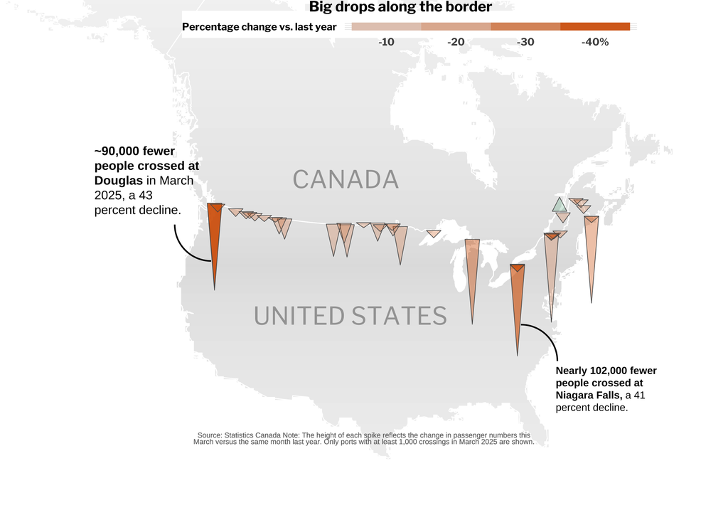

```r
# create a mask for areas within the bounding box
bbox_polygon <- st_polygon(list(rbind(
  c(bbox_expanded[1], bbox_expanded[2]),
  c(bbox_expanded[3], bbox_expanded[2]),
  c(bbox_expanded[3], bbox_expanded[4]),
  c(bbox_expanded[1], bbox_expanded[4]),
  c(bbox_expanded[1], bbox_expanded[2])
))) |>
  st_sfc(crs = st_crs(countries_proj))

# create the main plot with vertical gradient within countries
main_plot <- ggplot() +
  # add white background
  geom_raster(data = gradient_data,
              aes(x = x, y = y),
              fill = "white") +
  # add the vertical gradient within countries only
  geom_raster(data = gradient_data |> filter(within_countries),
              aes(x = x, y = y, fill = final_color, alpha = alpha_value)) + # alpha here is for gradient
  # use identity scales for the custom colors
  scale_fill_identity() +
  scale_alpha_identity() + # this will apply to gradient's alpha, and later legend rect's alpha
  # add country boundaries
  geom_sf(data = countries_proj,
          fill = NA, color = "white", linewidth = 0.3) +
  # Great Lakes
  geom_sf(data = lakes_proj,
          fill = "white", color = "white", linewidth = 0.1) +
  # triangle spikes with alpha based on raw change magnitude
  geom_sf(
    data = triangle_sf,
    aes(fill = if_else(perc_change < 0, I('#d65f00'), I('#2b9d6c'))),
    size = 0.8,
    alpha = pmin(triangle_sf$alpha_value, .7)
  ) +
  scale_fill_identity() +
  # triangle color scale
  # scale_color_manual(
  #   values = c("negative" = "#d65f00", "positive" = "#2b9d6c"),
  #   guide = "none"
  # ) +
  # coordinate system
  coord_sf(
    xlim = c(-4e6, 4e6),
    ylim = c(-1.75e6, 2.1e6),
    expand = FALSE,
    clip = 'off'
  ) +
  # clean theme
  theme_void() +
  theme(
    plot.title = element_markdown(hjust = 0.5, size = 14, family = 'franklin', margin = margin(t = -10, b = 10)),
    plot.background = element_rect(fill = "white", color = NA),
    panel.background = element_rect(fill = "white", color = NA),
    legend.position = 'none' # ggplot's auto legend is off, we are making a manual one
  )

# function to create the 1/4 circles for Douglas and Niagara Falls callouts
draw_quarter_circles <- function(start, end, radius = 400e3, x_offset = 0, y_offset = 0){

  # get angles and coords for a quarter of a acircle
  angles <- seq(start, end, length.out = 1000) # reduced length.out for efficiency
  # radius <- radius # already an argument
  x_coords <- radius * cos(angles)
  y_coords <- radius * sin(angles)

  # test with different offesets to match article's callout positioning
  x_coords_with_offset <- x_coords + x_offset
  y_coords_with_offset <- y_coords + y_offset

  # assign values to a tibble
  quarter_circle_data <- tibble(x = x_coords_with_offset, y = y_coords_with_offset)

  # draw said 1/4 circles
  path <- geom_path(
    data = quarter_circle_data, aes(x = x, y = y) # simplified aes
  )

  return(path)
}

theme_set_custom()

# draw 1/4 circles
main_plot_with_qrt_circles <-
  main_plot +
  geom_text(
    aes(x = -150e3,
        y = -550e3,  label = 'UNITED STATES'),
    family = 'franklin',
    size = 6,
    color = '#a3a3a3'
  ) +
  geom_text(
    aes(x = -200e3,
        y = 950e3,  label = 'CANADA'),
    family = 'franklin',
    size = 6,
    color = '#a3a3a3'
  ) +
  # douglas 1/4 circle
  draw_quarter_circles(start = pi, end = 3 * pi/2, x_offset = -150e3 * 11.2, y_offset = -550e3 + 100e4) +
  # niagara 1/4 circle
  draw_quarter_circles(start = 0, end = pi/2, x_offset = -150e3 * -11.5, y_offset = -550e3 - 50e4)

call_outs_tibble <-
  tibble(
    label = c(
      "<b>~90,000 fewer<br> people crossed at<br> Douglas</b> in March<br>2025, a 43<br>percent decline.",
      "<b>Nearly 102,000 fewer <br> people crossed at <br>Niagara Falls,</b> a 41 <br> percent decline."
    ),
    x = c(-150e3 * 15, -150e3 * -14),
    y = c(-550e3 + 100e4, -550e3 - 75e4),
    hjust = c(.5, 0.05),
    vjust = c(0, 0.6)
  )

# add legend elements to the plot
legend_box <- pmin(
  triangle_sf$alpha_value, .7
  ) |>
  sort() |>
  enframe() |>
  mutate(
    normalized_values_01 = (value - min(value)) / (max(value) - min(value)),
    color_bins = case_when(
      normalized_values_01 <= .25 ~ '#e3cabd-10',
      normalized_values_01 <= .50 ~ '#e0b69e-20',
      normalized_values_01 <= .75 ~ '#db956a-30',
      normalized_values_01 <=  1  ~ '#d76c21-40%',
      TRUE ~ '#c7d8d0'
      ),
    labels = paste0('-', word(color_bins, -1, sep = '-')),
    color_bins = word(color_bins, 1, sep = '-')
  ) |>
  select(color_bins, labels) |>
  distinct() |>
  ggplot(aes(x = labels, y = .5, fill = I(color_bins))) +
  geom_tile() +
  labs(
    x = NULL,
    y = 'Percentage change vs. last year'
    ) +
  # ggtitle(label = '<b>Big drops along the border<b>') +
  theme(
    axis.title.y  = element_text(angle = 0, size = 7, vjust = .5, face = 'bold'),
    axis.text.x = element_text(size = 7, face = 'bold'),# vjust = .5, hjust = -1,
    axis.text.y = element_blank(),
    plot.background = element_rect(fill = "white", color = NA),
    panel.background = element_rect(fill = "white", color = NA),
    panel.grid.major.x = element_blank(),
    panel.grid.major.y = element_blank(),
    legend.position = 'none',
    plot.margin = margin(t = 8)
  )
# plot callouts
final_plot <-
  main_plot_with_qrt_circles +
  geom_textbox(
    data = call_outs_tibble,
    aes(x = x, y = y, label = label, hjust = hjust, vjust = vjust),
    family = 'Libre Franklin',
    width = unit(0.2, "npc"),
    fill = NA,
    size = c(3, 2.5),
    color = 'black',
    box.colour = NA,
    orientation = "upright"
  )
# plot legend box along with its (legend) name
final_plot_with_legend <- final_plot +
  annotation_custom(
    grob = ggplotGrob(legend_box),
    xmin = -2e6, xmax = 3e6,
    ymin = 2.5e6, ymax = 2.8e6
  )

# plot final with title using geom_text() to avoid running into margin/rendering erros + adding caption to plot
final_plot_with_legend +
  geom_text(
    aes(x = 0, y = 2.85e6, label = "Big drops along the border"),
    family = 'franklin',
    size = 3.5,
    fontface = 'bold',
    color = 'black',
    hjust = 0.3,
    vjust = 0.5
  ) +
  labs(
  caption = "<span style='color:#707070; text-align: justify; width: 100%; display: block; padding-top: 25px;'>Source: Statistics Canada Note: The height of
  each spike reflects the change in passenger numbers this<br>March versus the same month last year. Only ports with at least 1,000 crossings in March 2025
  are shown.</span>"
  ) +
  theme(
    plot.caption = element_markdown(margin(t = 50), size = 5, hjust = .5)
    )
```

Overall, I found this article powerful, clear, and its authors original in their use of data, so truly an enjoyable experience to have worked on ‘deconstructing’ the article backend to match the outputs as closely as I could.. thank you for taking the time to read this and more to come !